# cap2 - Packages and Help Packages

Washington Candeia de Araujo

April 25, 2018

Agora você tem uma função que simula rolar um par de dados. Vamos deixar as coisas um pouco mais interessantes por manipular os dados a seu favor. A casa sempre ganha, não é? Vamos fazer os dados mostrarem números mais altos com um pouco mais de frequência do que os números pequenos.

Antes de manipular os dados, devemos nos certificar de que eles estão prontos para iniciar. Duas ferramentas o ajudarão com isso: *repetition* e *visualization*. Por coincidência, estas ferramentas são também dois dos superpoderes mais usados no mundo da ciência de dados.

Nós repetiremos nosso lançamento de dados com uma função chamada `replicate`, e nós visualizaremos nossos lançamentos com uma função chamada `qplot`. Esta última não vem com o R quando você o baixa; `qplot` vem em um pacote R. Muitas das ferramentas mais úteis de R vem nesses pacotes, então vamos tomar um tempo para ver o que são os pacotes R e como você pode usá-los.

## Packages

*Let’s make it for a spin* (vamos dar uma volta com `qplot`).  
Em primeiro lugar, `qplot` significa *quick plots*. Por exemplo, se fornecermos para esta função dois vetores de igual comprimento, ela fornecerá um *scatterplot*, ou seja, um gráfico de distribuição. O primeiro vetor será um conjunto de valores **x** e o segundo vetor um conjunto de valores **y**.

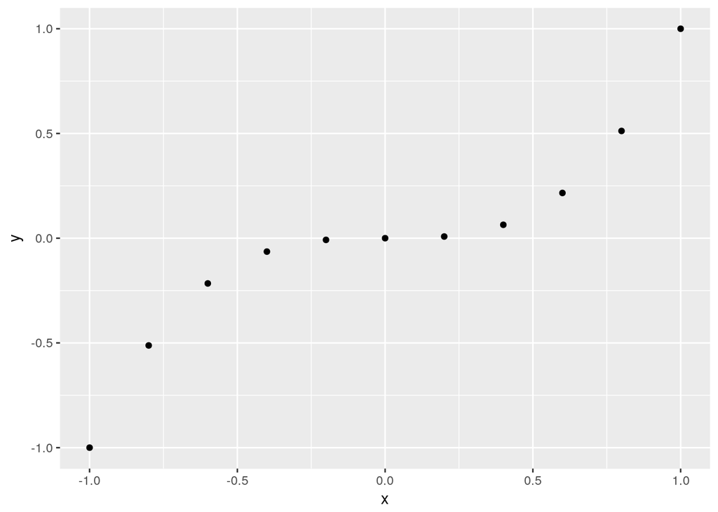

```r
library('ggplot2')
# Vetor 1
x <- c(-1, -0.8, -0.6, -0.4, -0.2, 0, 0.2, 0.4, 0.6, 0.8, 1)
# Vetor 2
y <- x^3

# qplot
qplot(x, y)
```

Vamos criar um histograma:

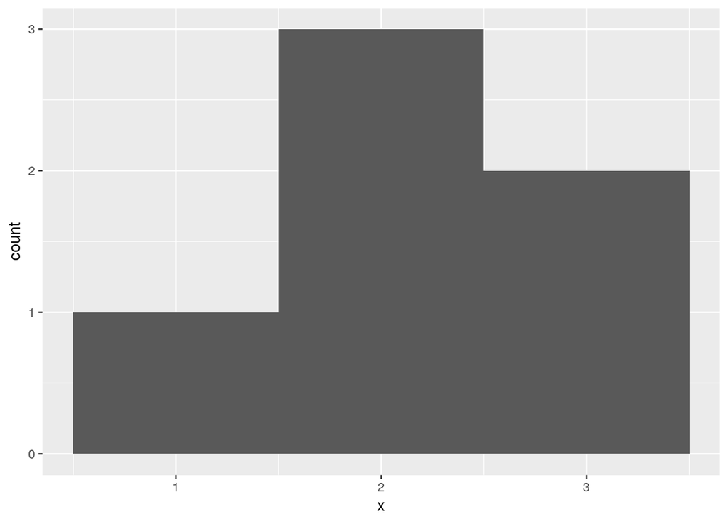

```r
x <- c(1, 2, 2, 2, 3, 3)
qplot(x, binwidth = 1)
```

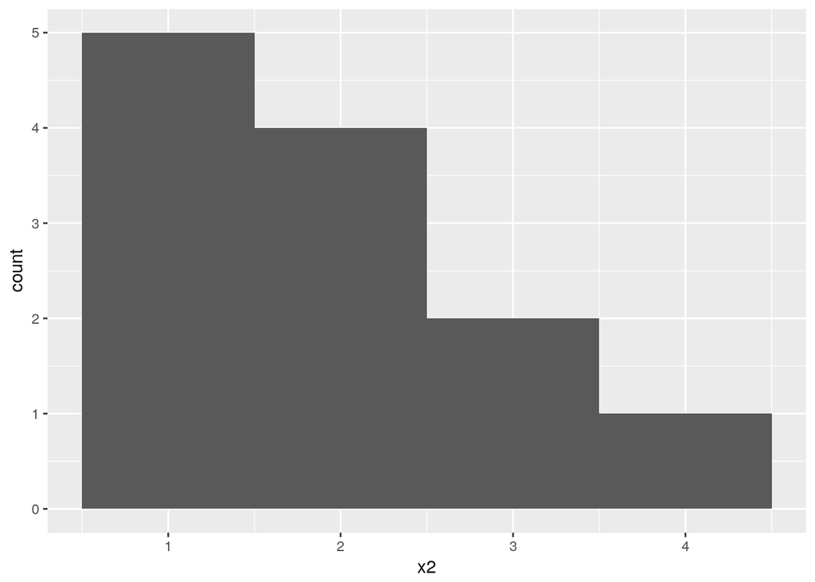

```r
x2 <- c(1, 1, 1, 1, 1, 2, 2, 2, 2, 3, 3, 4)
qplot(x2, binwidth = 1)
```

**Criando a funçao para lançar os dois dados**

```r
roll <- function(bones = 1:6){
  dice <- sample(bones, size = 2, replace = T)
  sum(dice)
}
```

### Replicate prove uma forma de repetir um comando R multiplas vezes

Podemos usar a função `rolls` várias vezes, somando lançamento a lançamento. Podemos inclusive utilizar a função `qplot` para obter histograma que nos mostre qual o valor de soma mais frequente. Porém, se precisássemos lançar 10000 vezes, ficaria muito cansativo. Desta forma, podemos lançar mão de outra função em R que poupará nosso tempo, e ela é `replicate`. Ela replicará quantas vezes desejarmos, uma determinada ação, como é o caso de lançar os dados utilizando a função `roll`.

> Primeiro argumento é o número de vezes que se quer repetir o comando

```r
# Exemplo: repetir três vezes a soma 1 + 1
replicate(3, 1 + 1)
```

```
## [1] 2 2 2
```

```r
# Repetir o uso de nossa função roll 10x
replicate(10, roll())
```

```
##  [1]  7  7  8 10  6  8  7  4  9 11
```

Agora sim, poderemos averiguar se nossos dados são confiáveis:

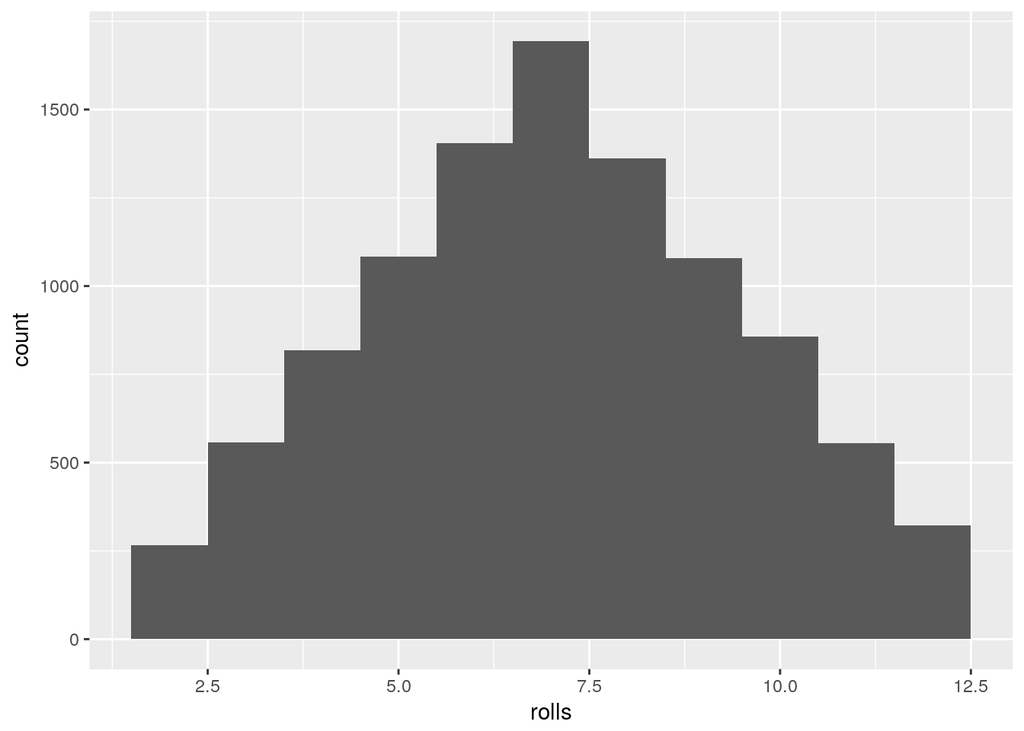

```r
rolls <- replicate(10000, roll())
# Gerar um histograma para ver suas frequências
qplot(rolls, binwidth = 1)
```

Ao que parece, sim. Pois as distribuições de frequências das nossas somas estão de acordo com padrão esperado.

Porém, se nós quiséssemos manipular nossos dados (literalmente), fazendo com que a frequência de uma determinada soma seja maior que outra, por exemplo 6 + 6. Isso aumentaria o valor da soma, movendo as maiores frequências para a direita deste histograma.

Para isso, basta fazer uma modificação no nosso uso da função `sample`. Adicionar um novo argumento, no parâmetro `prob`.

Se observarmos como é o valor esperado (justo) de probabilidade de lançamento de um dado, veremos que cada faca terá uma mesma probabilidade de 1/6. Veja a tabela:

| Número | Probabilidade justa | Probabilidade Ajustada |
| --- | --- | --- |
| 1 | 1/6 | 1/8 |
| 2 | 1/6 | 1/8 |
| 3 | 1/6 | 1/8 |
| 4 | 1/6 | 1/8 |
| 5 | 1/6 | 1/8 |
| 6 | 1/6 | 3/8 |

Note que o valor 6 (a face do dado) tem uma probabilidade aumentada para 3/8.

Para isso, um vetor com cada uma das probabilidades acima (coluna 3, **Probabilidade Ajustada**) deve ser inserido na nossa função `sample`, utilizando-o como um argumento para `prob`.

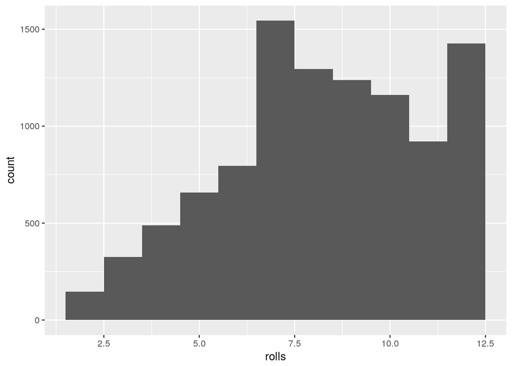

```r
roll <- function(bones = 1:6){
  dice <- sample(bones, size = 2, replace = TRUE, prob = c(1/8, 1/8, 1/8, 1/8, 1/8, 3/8))
  sum(dice)
}

# Agora, utilizando a funçao replicate para lançar 10000x
rolls <- replicate(10000, roll())
qplot(rolls, binwidth = 1)
```

**Note como as frequências foram modificadas.**